# Final Project: Bank Customer Churn

2024-06-15

# Introduction

While the mere acquisition of new customers remains a large aspect of conducting business, retaining current customers is an integral part of the success and longevity of a company. Oftentimes, it’s more expensive for companies to gain new clients, than maintaining high rates of retention for current customers. By prioritizing customer retention, companies are spending less money while developing stronger bonds with their current set of clientele, ultimately improving the status and reputation of the company. Knowing which variables most greatly correlate with customer churn is incredibly insightful information for companies, as now that they’ve identified the facets of customer service and experience that are leading to a loss of customers, they can improve them.  
This sentiment extends to the industry of banking; customers are key to the operation and maintaining their company is crucial. Banking is a lifelong endeavor; individuals utilize banks and bank accounts as young as the age of 13 years old and will likely require the service of a bank for the rest of their life. Additionally, when bank customers have had a good experience with the particular bank they’re using, they can influence their children and/or relatives to join the same bank, meaning the company has acquired new customers through the maintenance of current relationships. The decision to stay at a bank can be impacted by a plethora of different variables. The following project operates to discover the variables that impact bank customer churn most greatly, utilizing the Bank Customer Churn data set by Kaggle user Radheshyam Kollipara to create a binary classification model that predicts customer churn. Regarding this particular data set, we’ll specifically look at the outcome variable, **exited**, as it’s binary values are indicative of whether or not a customer left the bank.  
We’ll begin, by importing, exploring, and tidying our data set. From there, we’ll utilize machine learning techniques to split our data and create and run models. We’ll pit our models against each other to determine which fits the data set best, and then proceed to analyze our best model.  
Access the full data set here: https://www.kaggle.com/datasets/radheshyamkollipara/bank-customer-churn?resource=download

## Import Data

```r
library(glmnet)
library(janitor)
library(themis)
library(skimr)
library(forcats)
library(tidymodels)
library(ISLR)
library(ISLR2)
library(yardstick)
library(tidyverse)
library(caret)
library(ggthemes)
library(corrplot)
library(discrim)
library(corrr)
library(klaR)
library(ggplot2)
library(kknn)
library(dplyr)
library(kableExtra)
library(dplyr)
library(vip)
tidymodels_prefer()

ccr_raw <- read_csv('/Users/leenaanqud/Downloads/Customer-Churn-Records.csv')
head(ccr_raw)
```

```
## # A tibble: 6 × 18
##   RowNumber CustomerId Surname CreditScore Geography Gender   Age Tenure Balance
##       <dbl>      <dbl> <chr>         <dbl> <chr>     <chr>  <dbl>  <dbl>   <dbl>
## 1         1   15634602 Hargra…         619 France    Female    42      2      0
## 2         2   15647311 Hill            608 Spain     Female    41      1  83808.
## 3         3   15619304 Onio            502 France    Female    42      8 159661.
## 4         4   15701354 Boni            699 France    Female    39      1      0
## 5         5   15737888 Mitche…         850 Spain     Female    43      2 125511.
## 6         6   15574012 Chu             645 Spain     Male      44      8 113756.
## # ℹ 9 more variables: NumOfProducts <dbl>, HasCrCard <dbl>,
## #   IsActiveMember <dbl>, EstimatedSalary <dbl>, Exited <dbl>, Complain <dbl>,
## #   `Satisfaction Score` <dbl>, `Card Type` <chr>, `Point Earned` <dbl>
```

```r
colSums(is.na(ccr_raw)) # Check missing values
```

```
##          RowNumber         CustomerId            Surname        CreditScore
##                  0                  0                  0                  0
##          Geography             Gender                Age             Tenure
##                  0                  0                  0                  0
##            Balance      NumOfProducts          HasCrCard     IsActiveMember
##                  0                  0                  0                  0
##    EstimatedSalary             Exited           Complain Satisfaction Score
##                  0                  0                  0                  0
##          Card Type       Point Earned
##                  0                  0
```

```r
str(ccr_raw) # The data set has 4 character variables and 14 numeric variables.
```

```
## spc_tbl_ [10,000 × 18] (S3: spec_tbl_df/tbl_df/tbl/data.frame)
##  $ RowNumber         : num [1:10000] 1 2 3 4 5 6 7 8 9 10 ...
##  $ CustomerId        : num [1:10000] 15634602 15647311 15619304 15701354 15737888 ...
##  $ Surname           : chr [1:10000] "Hargrave" "Hill" "Onio" "Boni" ...
##  $ CreditScore       : num [1:10000] 619 608 502 699 850 645 822 376 501 684 ...
##  $ Geography         : chr [1:10000] "France" "Spain" "France" "France" ...
##  $ Gender            : chr [1:10000] "Female" "Female" "Female" "Female" ...
##  $ Age               : num [1:10000] 42 41 42 39 43 44 50 29 44 27 ...
##  $ Tenure            : num [1:10000] 2 1 8 1 2 8 7 4 4 2 ...
##  $ Balance           : num [1:10000] 0 83808 159661 0 125511 ...
##  $ NumOfProducts     : num [1:10000] 1 1 3 2 1 2 2 4 2 1 ...
##  $ HasCrCard         : num [1:10000] 1 0 1 0 1 1 1 1 0 1 ...
##  $ IsActiveMember    : num [1:10000] 1 1 0 0 1 0 1 0 1 1 ...
##  $ EstimatedSalary   : num [1:10000] 101349 112543 113932 93827 79084 ...
##  $ Exited            : num [1:10000] 1 0 1 0 0 1 0 1 0 0 ...
##  $ Complain          : num [1:10000] 1 1 1 0 0 1 0 1 0 0 ...
##  $ Satisfaction Score: num [1:10000] 2 3 3 5 5 5 2 2 3 3 ...
##  $ Card Type         : chr [1:10000] "DIAMOND" "DIAMOND" "DIAMOND" "GOLD" ...
##  $ Point Earned      : num [1:10000] 464 456 377 350 425 484 206 282 251 342 ...
##  - attr(*, "spec")=
##   .. cols(
##   ..   RowNumber = col_double(),
##   ..   CustomerId = col_double(),
##   ..   Surname = col_character(),
##   ..   CreditScore = col_double(),
##   ..   Geography = col_character(),
##   ..   Gender = col_character(),
##   ..   Age = col_double(),
##   ..   Tenure = col_double(),
##   ..   Balance = col_double(),
##   ..   NumOfProducts = col_double(),
##   ..   HasCrCard = col_double(),
##   ..   IsActiveMember = col_double(),
##   ..   EstimatedSalary = col_double(),
##   ..   Exited = col_double(),
##   ..   Complain = col_double(),
##   ..   `Satisfaction Score` = col_double(),
##   ..   `Card Type` = col_character(),
##   ..   `Point Earned` = col_double()
##   .. )
##  - attr(*, "problems")=<externalptr>
```

I’ve imported necessary libraries and the data set. Based on brief initial exploration of the data, there are 10000 observations and 18 variables. There are no missing values. The 18 variables stored in the data set are defined below.  
**RowNumber**: corresponds to the record (row) number and has no effect on the output.  
**CustomerId**: contains random values and has no effect on customer leaving the bank.  
**Surname**: the surname of a customer has no impact on their decision to leave the bank.  
**CreditScore**: can have an effect on customer churn, since a customer with a higher credit score is less likely to leave the bank.  
**Geography**: a customer’s location can affect their decision to leave the bank.  
**Gender**: it’s interesting to explore whether gender plays a role in a customer leaving the bank.  
**Age**: this is certainly relevant, since older customers are less likely to leave their bank than younger ones.  
**Tenure**: refers to the number of years that the customer has been a client of the bank. Normally, older clients are more loyal and less likely to leave a bank.  
**Balance**: also a very good indicator of customer churn, as people with a higher balance in their accounts are less likely to leave the bank compared to those with lower balances.  
**NumOfProducts**: refers to the number of products that a customer has purchased through the bank.  
**HasCrCard**: denotes whether or not a customer has a credit card. This column is also relevant, since people with a credit card are less likely to leave the bank.  
**IsActiveMember**: active customers are less likely to leave the bank.  
**EstimatedSalary**: as with balance, people with lower salaries are more likely to leave the bank compared to those with higher salaries.  
**Exited**: whether or not the customer left the bank.  
**Complain**: customer has complaint or not.  
**Satisfaction Score**: Score provided by the customer for their complaint resolution.  
**Card Type**: type of card hold by the customer.  
**Points Earned**: the points earned by the customer for using credit card.

## Data Tidying (P1)

In the initial search of the data set, I noticed that some of the variable names have spaces in them, and all the variables use capital letters. To mitigate any issues that can potentially arise from these naming conventions, I’ll use clean_names() to tidy the names. Additionally, based on the description of the variables listed above, originating from the source of the data set, I’ll be dropping the variables **RowNumber**, **CustomerId**, and **Surname**, as they’re listed as having no impact on customer churn.

```r
ccr_raw %>% select(-RowNumber, -CustomerId, -Surname) %>%
  clean_names() -> ccr_updated

head(ccr_updated)
```

```
## # A tibble: 6 × 15
##   credit_score geography gender   age tenure balance num_of_products has_cr_card
##          <dbl> <chr>     <chr>  <dbl>  <dbl>   <dbl>           <dbl>       <dbl>
## 1          619 France    Female    42      2      0                1           1
## 2          608 Spain     Female    41      1  83808.               1           0
## 3          502 France    Female    42      8 159661.               3           1
## 4          699 France    Female    39      1      0                2           0
## 5          850 Spain     Female    43      2 125511.               1           1
## 6          645 Spain     Male      44      8 113756.               2           1
## # ℹ 7 more variables: is_active_member <dbl>, estimated_salary <dbl>,
## #   exited <dbl>, complain <dbl>, satisfaction_score <dbl>, card_type <chr>,
## #   point_earned <dbl>
```

There are no missing values in our data set, so there were none to deal with in the tidying of the data. With the three specified variables removed, there are now 10,000 observations and 15 variables. Variables names no longer have capital letters and have underscores in place of spaces. For example, the variable **HasCrCard** is now **has_cr_card**.

# Exploratory Data Analysis

To begin to evaluate the impact of our predictor variables on our outcome variable, **exited**, let’s create a correlation matrix of the numeric variables.

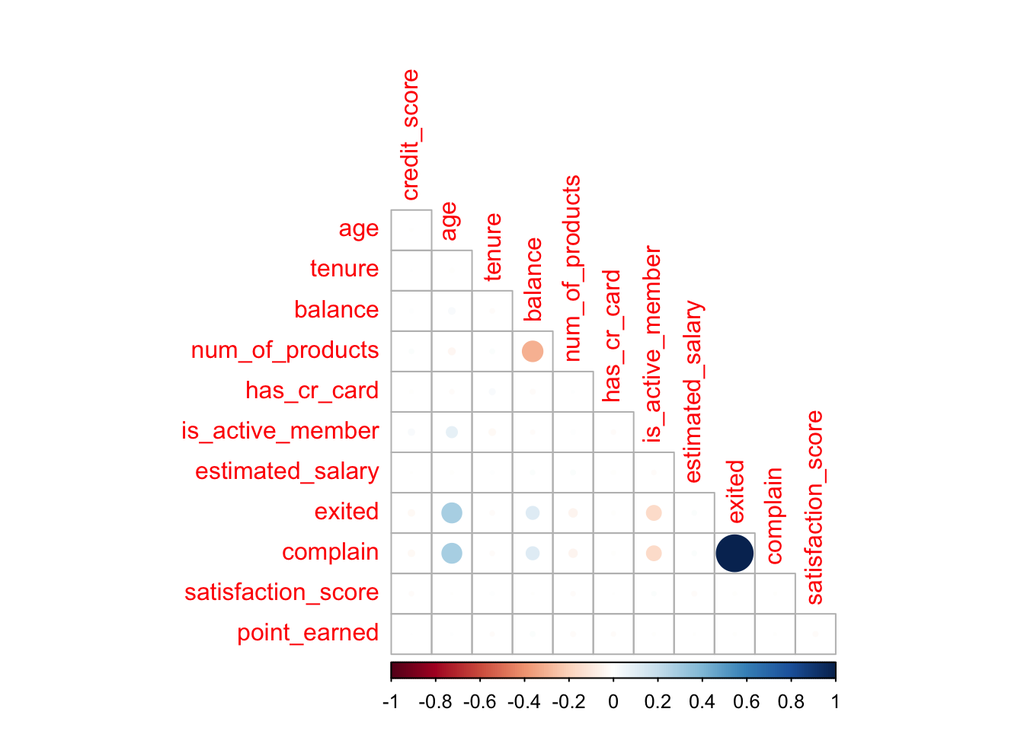

```r
ccr_updated %>%
  select(is.numeric) %>%
  cor() %>%
  corrplot(type= 'lower', diag= FALSE, method= 'circle' )
```

Here, we can see that **balance** and **age** are slightly positively correlated with **exited**. This means that as balances go up, customers are more likely to exit. Similarly, as age increases, likelihood of exiting increases. **Exited** is slightly negatively correlated with **is_active_member** and **num_of_products**. **Complain** and **exited** are perfectly positively correlated with a score of 1. The same variables that are slightly positively and negatively correlated with **exited** are also correlated with **complain**, indicating collinearity. To handle the collinearity, I’ll drop **complain** in my final tidying of the data set.  
Not associated with exited are **num_of_products** and **balance** being slightly negatively correlated with each other, while **is_active_member** and **age** are slightly positively correlated with each other.  
Next, let’s explore the distribution of our outcome variable.

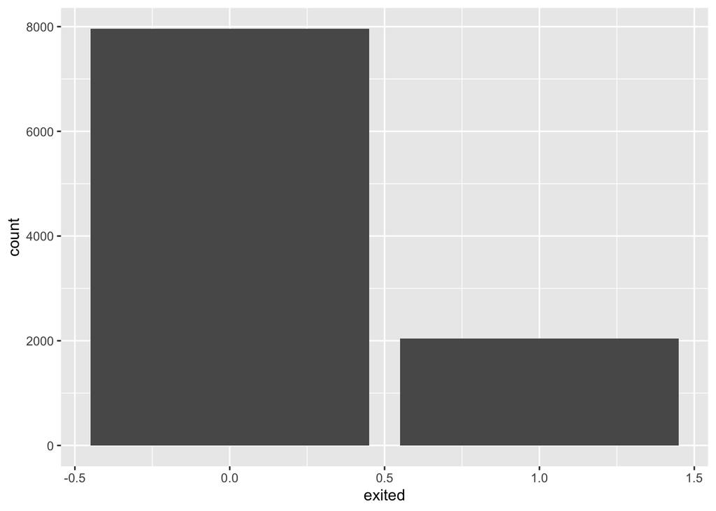

```r
ccr_updated %>%
  ggplot(aes(x=exited)) + geom_bar() # Histogram distribution
```

```r
ccr_updated %>%
  select(exited) %>%
  table() # Out of our 10,000 observations, 7,962 do not exit the bank, while 2,038 do
```

```
## exited
##    0    1
## 7962 2038
```

Here we can see that our data is moderately imbalanced with around 80% of customers not exiting and 20% exiting. As such, I will be upsampling the data during the recipe stage, as the imbalance in the data could result in a model’s bias towards predicting when customers do not exit. Additionally, this imbalance indicates that the best metric to determine the optimal model is ROC AUC. ROC AUC stands for Receiver Operating Characteristic Area Under Curve. It measures specificity versus sensitivity in binary classification, meaning it provides measurements for our rates of both true and false positives and negatives.  
They are defined as the following:

- **True Positive**: our model predicts a customer will exit the bank, and the customer does exit the bank
- **False Positive**: our model predicts a customer will exit the bank, but the customer does not exit the bank
- **True Negative**: our model predicts a customer will not exit the bank, and the customer does not exit the bank
- **False Negative**: our model predicts a customer will not exit the bank, but the customer does exit the bank  
  With that unit of measurement in mind, let’s further explore **exited**’s correlation with **balance** and **age** through a combination of box and violin plots.

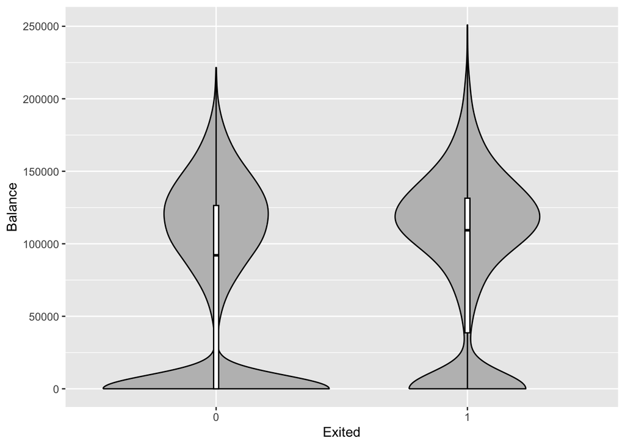

```r
ccr_updated %>%
  ggplot(aes(x=reorder(exited, balance), y = balance)) +
  geom_violin(fill = "gray", color = "black") +
  geom_boxplot(width=0.02, fill = "white", color = "black") +
  labs(x = "Exited",
       y = "Balance")
```

Taking a look at customers that do not exit the bank, there’s a large influx of individuals with low balances as shown by the width of the violin plot. This may indicate that these are people just joining the bank, as new customers might not have funds in their accounts yet and are unlikely to leave if they’ve just joined. This is reflected in the longer interquartile range of those that stay. This pattern, while much less drastic, is reflected in those that leave, perhaps indicating people are emptying their accounts before exiting the bank. However, customers that exit have a larger range of balances in general. The median balance of those that stay is less than those that leave.  
The median balance of those that stay is slightly under $100,000, while those that exit is higher at around $115,000.

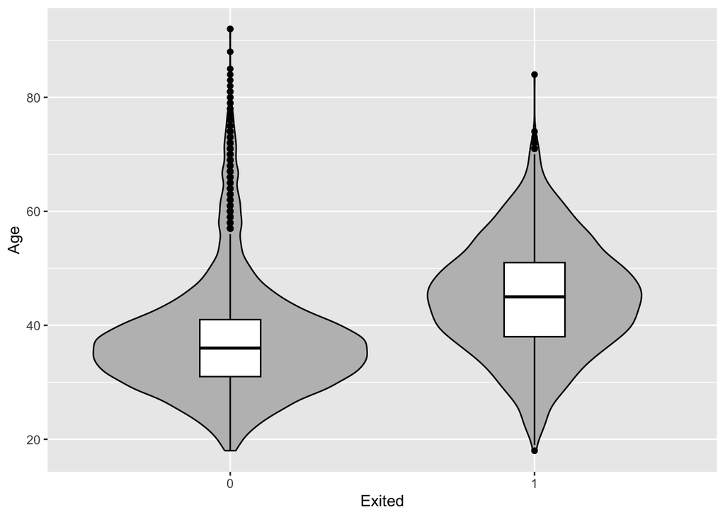

```r
ccr_updated %>%
  ggplot(aes(x=reorder(exited, age), y = age)) +
  geom_violin(fill = "gray", color = "black") +
  geom_boxplot(width=0.2, fill = "white", color = "black") +
  labs(x = "Exited",
       y = "Age")
```

While the median age for customers that do not exist is around 35, there is a significant number of outliers representing customers of 55+ years of age that stay at the bank. This may be because they are long-term bank customers and are loyal to this bank in particular, or because it may seem illogical to change banks at their older age. The violin plot indicates that a lower probability of customers stay at the bank past the age of 50.  
The median age for customers that exit the bank is 45. The ages of those that exist has a greater interquartile range, indicated in the violin plot by the more spread slope around the median (in comparison to the slope around the median for customers that do not exit). While there are still outliers, there are much less, as majority of the data is around the interquartile range.

## Data Tidying (P2)

In the first step of EDA, we discovered that there were 3 character variables and 12 numeric variables. Some of these numeric variables are binary, and are better suited to be stored as factors. Additionally, the remaining character variables are categorical and better analyzed as factors. Before exploring further, I’ll be altering the following variables to factors. At this stage, I’ll also remove **complain** from the data set to eliminate the collinearity we discovered earlier.

```r
ccr_updated %>%
  select(-complain) %>%
  mutate(num_of_products = as.factor(num_of_products),
         has_cr_card = as.factor(has_cr_card),
         is_active_member = as.factor(is_active_member),
         exited = as.factor(exited),
         satisfaction_score = as.factor(satisfaction_score)) -> ccr
```

Now, we’ll explore **exited**’s correlation with our non-numeric variables.

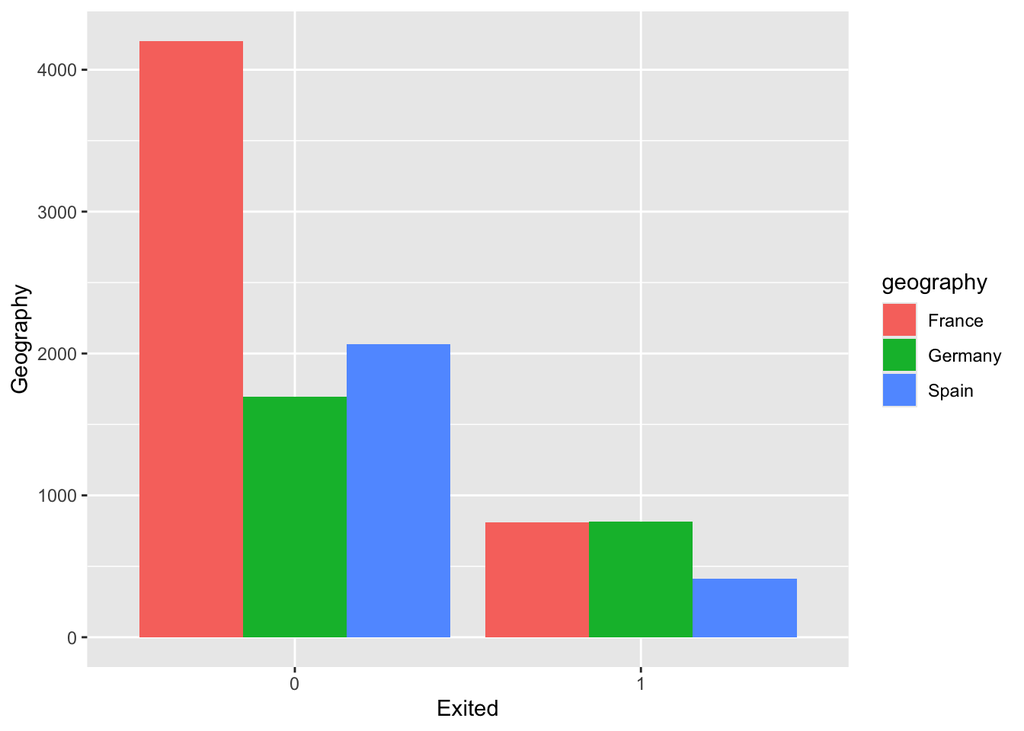

```r
# Geography
ccr %>%
  ggplot(aes(x = exited, fill = geography)) +
    geom_bar(position = "dodge") +
  labs(x = "Exited",
       y = "Geography")
```

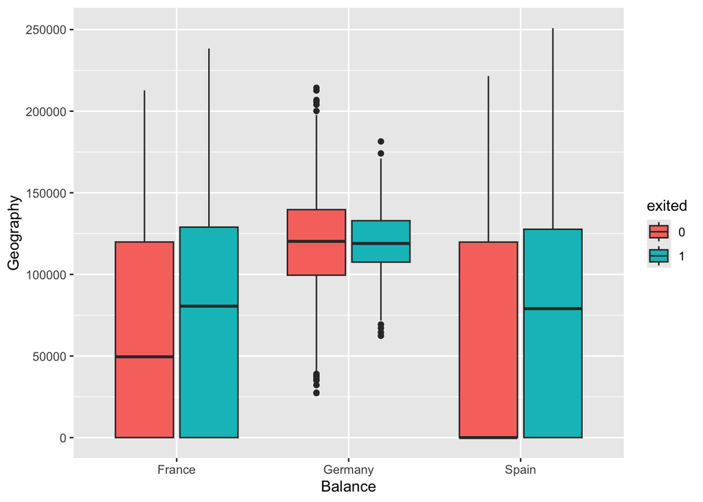

```r
ccr %>%
  ggplot(aes(x = geography, y = balance, fill = exited)) +
  geom_boxplot() +
  labs(x = "Balance",
       y = "Geography")
```

The bar graph indicates that customers from France and Germany leave the bank in similar numbers. In the box plot that displays the distribution of balances of individuals that do not exit or exit based on geography reveals that for France, the median balance of those that stay is lower than those that leave. In Spain, that same difference is far larger. Lastly, Germany has notable outliers despite the status of **exited**. The IQR’s are significantly smaller, and the median of those that stay is slightly higher than those that leave.

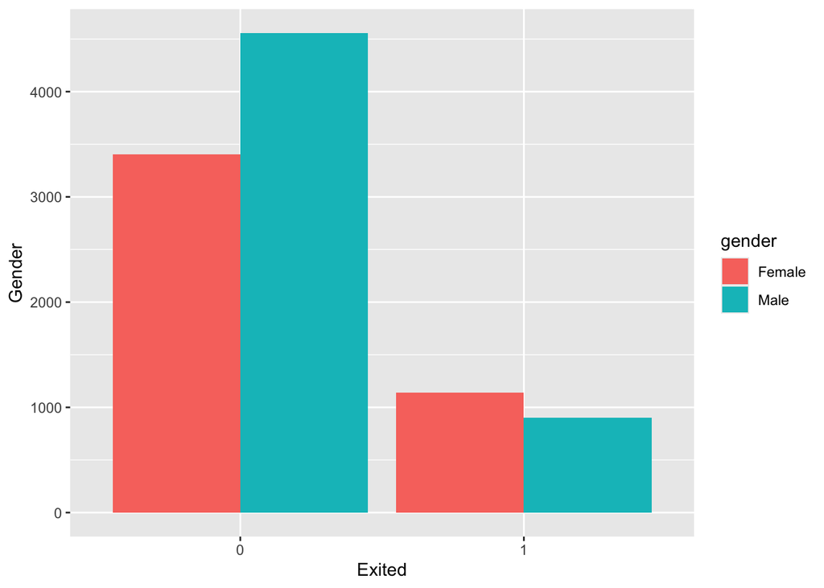

```r
# Gender
ccr %>%
  ggplot(aes(x = exited, fill = gender)) +
    geom_bar(position = "dodge") +
  labs(x = "Exited",
       y = "Gender")
```

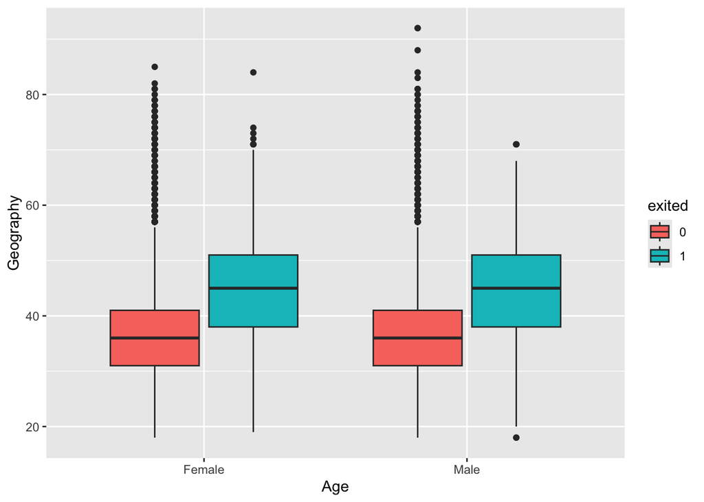

```r
ccr %>%
  ggplot(aes(x = gender, y = age, fill = exited)) +
  geom_boxplot() +
  labs(x = "Age",
       y = "Geography")
```

Women are slightly more likely to leave the bank than men, but men are more likely to maintain their status as bank customers.  
In the box plot that measures both gender and age against exited, the median age for both genders is higher in those that exit the bank. There are a number of outliers that do not exit the bank; for both males and females there’s older aged individuals who stay. This seems to indicate that, despite differences in gender, older individuals are more likely to leave the bank.

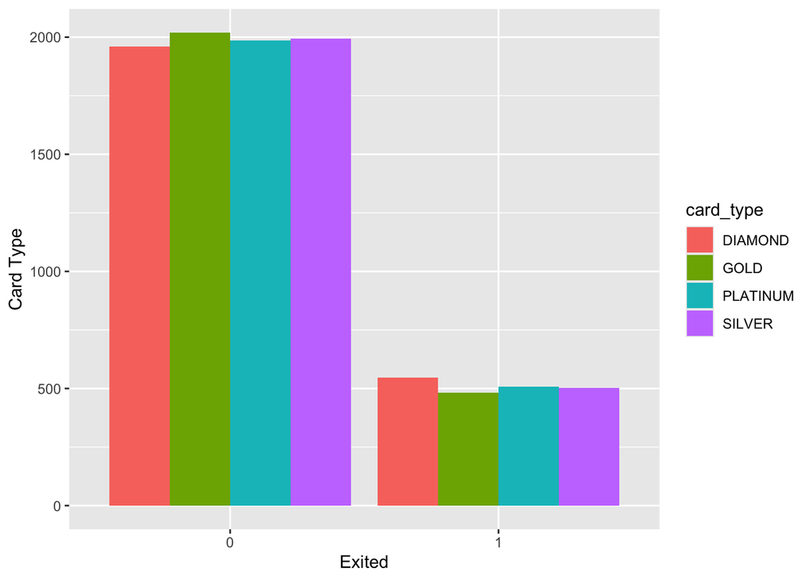

```r
# Card Type
ccr %>%
  ggplot(aes(x = exited, fill = card_type)) +
  geom_bar(position='dodge') +
  labs(x = "Exited",
       y = "Card Type")
```

Customers seem to be around equally likely to stay or leave the bank based on their card type. The imbalance of data demonstrated here likely mimics the imbalance of data of the outcome variable itself.

# Run Models

## Split, Stratify, & Create Recipe

Now that we’ve gained some more insight into both our outcome variable and its corresponding predictor variables, as well as their correlations, we’ll move on to our modeling stage. First, we’ll ensure reproducibility by setting a seed. Additionally, we’ll split our data into training and testing sets. This will ensure that our model is not evaluated on the data it was fit on, which would skew the accuracy of our model. We set the proportion of our split to .7, which places 6999 observations in our training set and 3001 in our testing set. We stratify the split on our outcome variable, **exited**, ensuring an approximately equal proportion among those that exit and do not exit in our training and testing sets. We’ll then utilize the technique of K-fold cross validation, which allows us to tune hyperparameters for different values and generalize our results by testing the models on multiple subsets of our data. We create the k-fold on our training data set, setting the folds to 5.

```r
set.seed(614)
ccr_split <- initial_split(ccr, strata=exited, prop=.7)
ccr_split
```

```
## <Training/Testing/Total>
## <6999/3001/10000>
```

```r
ccr_train <- training(ccr_split)
ccr_test <- testing(ccr_split)

ccr_folds <- vfold_cv(ccr_train, v=5, strata=exited)
```

```r
ccr_recipe <- recipe(exited ~., data=ccr_train) %>%
  step_normalize(all_numeric()) %>%
  step_dummy(all_nominal_predictors(), one_hot = TRUE) %>%
  step_upsample(exited, over_ratio = 0.5)

prep(ccr_recipe) %>%
  bake(new_data = ccr_train) %>%
  head() %>%
  kable() %>%
  kable_styling(full_width = F) %>%
  scroll_box(width = "100%", height = "200px")
```

| credit_score | age | tenure | balance | estimated_salary | point_earned | exited | geography_France | geography_Germany | geography_Spain | gender_Female | gender_Male | num_of_products_X1 | num_of_products_X2 | num_of_products_X3 | num_of_products_X4 | has_cr_card_X0 | has_cr_card_X1 | is_active_member_X0 | is_active_member_X1 | satisfaction_score_X1 | satisfaction_score_X2 | satisfaction_score_X3 | satisfaction_score_X4 | satisfaction_score_X5 | card_type_DIAMOND | card_type_GOLD | card_type_PLATINUM | card_type_SILVER |
| --- | --- | --- | --- | --- | --- | --- | --- | --- | --- | --- | --- | --- | --- | --- | --- | --- | --- | --- | --- | --- | --- | --- | --- | --- | --- | --- | --- | --- |
| -0.4433914 | 0.1986745 | -1.3819386 | 0.1207589 | 0.2089128 | -0.6767445 | 0 | 0 | 0 | 1 | 1 | 0 | 1 | 0 | 0 | 0 | 1 | 0 | 0 | 1 | 0 | 0 | 1 | 0 | 0 | 1 | 0 | 0 | 0 |
| 0.5053228 | 0.0093203 | -1.3819386 | -1.2247849 | -0.1157607 | -1.1460077 | 0 | 1 | 0 | 0 | 1 | 0 | 0 | 1 | 0 | 0 | 1 | 0 | 1 | 0 | 0 | 0 | 0 | 0 | 1 | 0 | 1 | 0 | 0 |
| 1.7876509 | 1.0507688 | 0.6850627 | -1.2247849 | -1.5688473 | -1.7834974 | 0 | 1 | 0 | 0 | 0 | 1 | 0 | 1 | 0 | 0 | 0 | 1 | 0 | 1 | 0 | 1 | 0 | 0 | 0 | 0 | 0 | 0 | 1 |
| -1.5589125 | 0.4827059 | -0.3484379 | 1.0558596 | -0.4433864 | -1.5842819 | 0 | 1 | 0 | 0 | 0 | 1 | 0 | 1 | 0 | 0 | 1 | 0 | 0 | 1 | 0 | 0 | 1 | 0 | 0 | 0 | 1 | 0 | 0 |
| 0.3489414 | -1.1268054 | -1.0374384 | 0.9362942 | -0.4991544 | -1.1814238 | 0 | 1 | 0 | 0 | 0 | 1 | 1 | 0 | 0 | 0 | 0 | 1 | 0 | 1 | 0 | 0 | 1 | 0 | 0 | 0 | 1 | 0 | 0 |
| -1.2774259 | -0.7480968 | 0.3405625 | 0.4131040 | -0.3524752 | -1.5267307 | 0 | 1 | 0 | 0 | 0 | 1 | 0 | 1 | 0 | 0 | 1 | 0 | 1 | 0 | 0 | 0 | 1 | 0 | 0 | 0 | 1 | 0 | 0 |

```r
ccr_recipe
```

[output not shown]

## Constructing & Fitting Models

### Elastic Net Regression:

Our first model to be created is an Elastic Net Logistic Regression model. Elastic net regression is suitable for this model when utilized in combination with tuning, as it uses both lasso and ridge regression to find a balance between both that optimizes the model based on hyperparameters. I begin by tuning mixture, $\alpha$, and penalty, $\lambda$, so the model finds it’s own balance between lasso and ridge regularization. I create the workflow and form a grid with ten levels. I then tune and plot the model’s performance based on our desired metric, ROC AUC.

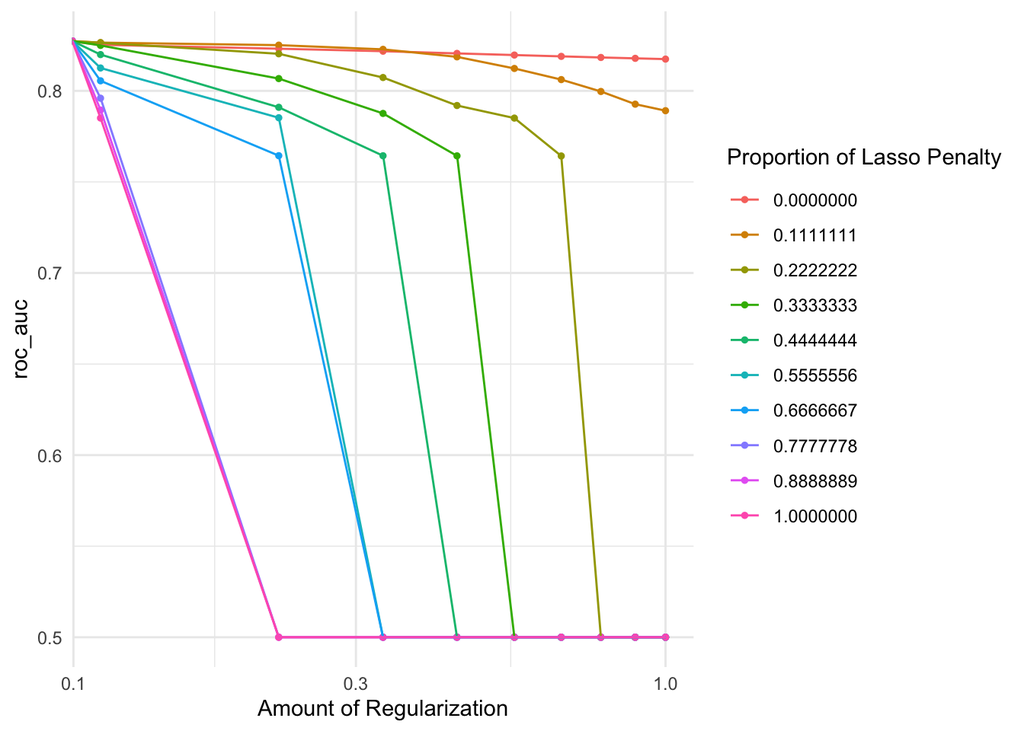

```r
# Construct Model
ccr_en <- logistic_reg(mixture = tune(),
                           penalty = tune()) %>%
  set_mode('classification') %>%
  set_engine('glmnet')

# Workflow
ccr_en_wf <- workflow() %>%
  add_model(ccr_en) %>%
  add_recipe(ccr_recipe)

# Create Grid
ccr_en_grid <- grid_regular(penalty(range = c(0, 1),
                                     trans = identity_trans()),
                        mixture(range = c(0, 1)),
                             levels = 10)
# Tune Grid
ccr_en_tune <- tune_grid(
  object = ccr_en_wf,
  resamples = ccr_folds,
  grid = ccr_en_grid
)

autoplot(ccr_en_tune, metric = 'roc_auc') + theme_minimal()
```

The plot indicates that models with lower penalty values have higher ROC AUC scores, which is better. Additionally, it seems like mixture values below 0.5 score better.

### KKNN:

The next model I selected was K-nearest neighbors, as neighbors can be tuned and used in a classification model. I followed the same steps as above, setting my range for neighbors to be between 1 and 10, as providing too many neighbors can result in overfitting. The model has 10 levels.

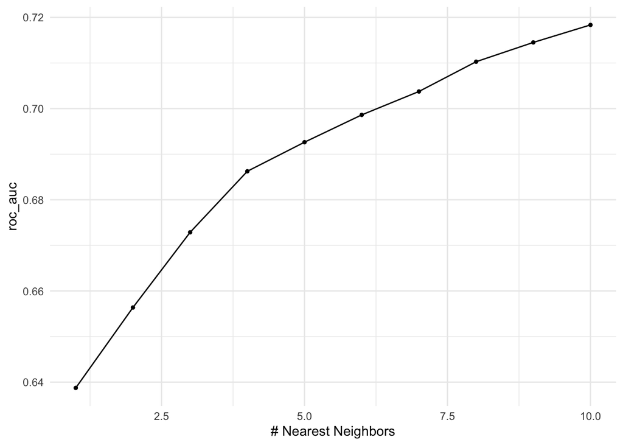

```r
# Construct Model
ccr_kknn <- nearest_neighbor(neighbors=tune()) %>%
  set_mode("classification") %>%
  set_engine("kknn")

# Workflow
ccr_kknn_wf <- workflow() %>%
  add_model(ccr_kknn) %>%
  add_recipe(ccr_recipe)

# Create Grid
ccr_kknn_grid <- grid_regular(levels=10,
                              neighbors(range = c(1, 10)))

# Tune Grid
ccr_kknn_tune <- tune_grid(
  object = ccr_kknn_wf,
  resamples = ccr_folds,
  grid = ccr_kknn_grid
  )

autoplot(ccr_kknn_tune, metric='roc_auc') + theme_minimal()
```

The plot illustrates that the greater the number of neighbors, the higher the ROC AUC score. We might be tempted to increase our range of neighbors to larger than 10, however, increasing the number of neighbors can also increase bias, so I’ll leave it as is.

## Logistic Regression

Next, I chose a simple logistic regression in order to include a model with a minor computational time. This model has no hyperparameters to be tuned, so resampling occurs on the folds.

```r
ccr_logreg <- logistic_reg() %>%
  set_engine('glm') %>%
  set_mode('classification')

ccr_logreg_wf <- workflow() %>%
  add_model(ccr_logreg) %>%
  add_recipe(ccr_recipe)

ccr_logreg_grid <- grid_regular(levels=10,
                         mixture(range=c(0,1)),
                         penalty())

ccr_logreg_tune <- tune_grid(
  object = ccr_logreg_wf,
  resamples = ccr_folds,
  grid = ccr_logreg_grid,
  control = control_grid(verbose = TRUE)
)
```

For uniformity of naming conventions, the last step has been assigned the name ‘tune’ despite there being no hyperparameters to be tuned.

### Random Forest:

The last model we’ll be creating and evaluating is a Random Forest model. These models are good at avoiding overfitting, so given the upsampling in the recipe, random forest is a good model to create. The hyperparameters mtry and min_n are tuned. Mtry represents the number of random predictors randomly sampled. Min_n represents the minimum number of data points per node. I’ve set trees to 500 to limit running time. I’ve set the range of mtry to between 1 and 13, encompassing the range of predictor variables. Our minimum number of nodes per group is between 2 and 10. There are 5 levels.

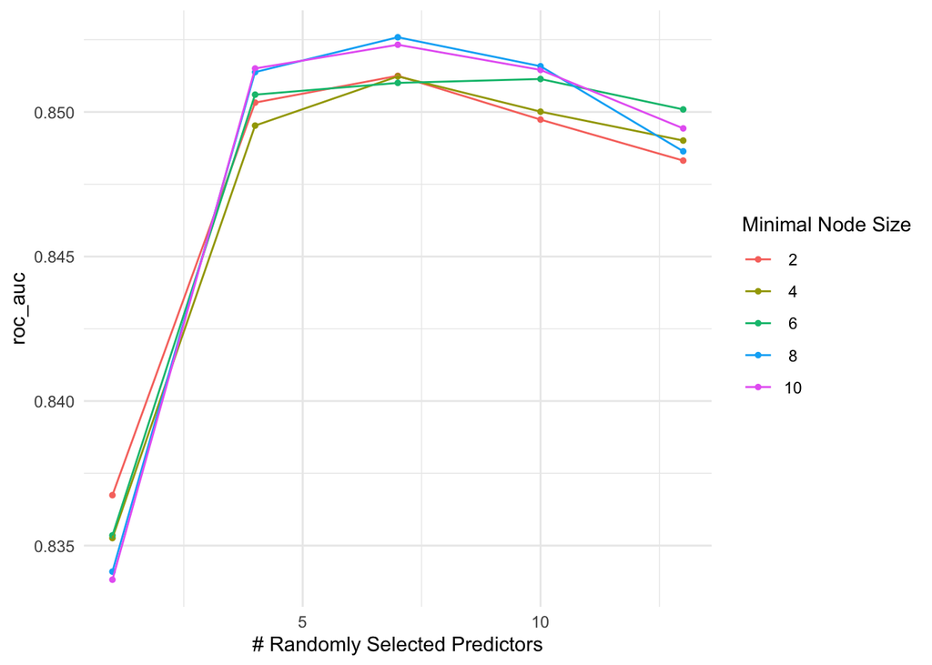

```r
ccr_rf <- rand_forest(mtry = tune(),
                      min_n = tune(),
                      trees = 500) %>%
  set_mode("classification") %>%
  set_engine("ranger", importance = "impurity")

# Workflow
ccr_rf_wf <- workflow() %>%
  add_model(ccr_rf) %>%
  add_recipe(ccr_recipe)

# Create Grid
ccr_rf_grid <- grid_regular(mtry(range = c(1, 13)),
                            min_n(range = c(2, 10)),
                            levels = 5)

# Tune Grid
ccr_rf_tune <- tune_grid(
  ccr_rf_wf,
  resamples = ccr_folds,
  grid = ccr_rf_grid
)

autoplot(ccr_rf_tune, metric = 'roc_auc') + theme_minimal()
```

As the number of randomly selected predictors increases, so does the ROC AUC score up until around 7 predictors where the scores begin to taper off.

# Model Comparisons

## Collect Metrics

Now that we’re done setting up, tuning, and fitting our models, it’s time to collect metrics. We will be measuring the effectiveness of each model using their ROC AUC scores. As stated previously, we’ve chosen ROC AUC as our metric because it handles the imbalance of our outcome variable better than merely using accuracy.

```r
# Elastic Net
best_en <- show_best(ccr_en_tune)
best_en
```

```
## # A tibble: 5 × 8
##   penalty mixture .metric .estimator  mean     n std_err .config
##     <dbl>   <dbl> <chr>   <chr>      <dbl> <int>   <dbl> <chr>
## 1       0   0.889 roc_auc binary     0.827     5 0.00750 Preprocessor1_Model081
## 2       0   0.667 roc_auc binary     0.827     5 0.00750 Preprocessor1_Model061
## 3       0   1     roc_auc binary     0.827     5 0.00750 Preprocessor1_Model091
## 4       0   0.556 roc_auc binary     0.827     5 0.00751 Preprocessor1_Model051
## 5       0   0.778 roc_auc binary     0.827     5 0.00751 Preprocessor1_Model071
```

```r
# KKNN
best_kknn <- show_best(ccr_kknn_tune)
best_kknn
```

```
## # A tibble: 5 × 7
##   neighbors .metric .estimator  mean     n std_err .config
##       <int> <chr>   <chr>      <dbl> <int>   <dbl> <chr>
## 1        10 roc_auc binary     0.718     5 0.00701 Preprocessor1_Model10
## 2         9 roc_auc binary     0.715     5 0.00721 Preprocessor1_Model09
## 3         8 roc_auc binary     0.710     5 0.00732 Preprocessor1_Model08
## 4         7 roc_auc binary     0.704     5 0.00722 Preprocessor1_Model07
## 5         6 roc_auc binary     0.699     5 0.00705 Preprocessor1_Model06
```

```r
# Logistic Regression
best_logreg <- show_best(ccr_logreg_tune)
best_logreg
```

```
## # A tibble: 1 × 6
##   .metric .estimator  mean     n std_err .config
##   <chr>   <chr>      <dbl> <int>   <dbl> <chr>
## 1 roc_auc binary     0.827     5 0.00747 Preprocessor1_Model1
```

```r
# Random Forest
best_rf <- show_best(ccr_rf_tune)
best_rf
```

```
## # A tibble: 5 × 8
##    mtry min_n .metric .estimator  mean     n std_err .config
##   <int> <int> <chr>   <chr>      <dbl> <int>   <dbl> <chr>
## 1     7     8 roc_auc binary     0.853     5 0.00379 Preprocessor1_Model18
## 2     7    10 roc_auc binary     0.852     5 0.00406 Preprocessor1_Model23
## 3    10     8 roc_auc binary     0.852     5 0.00387 Preprocessor1_Model19
## 4     4    10 roc_auc binary     0.852     5 0.00449 Preprocessor1_Model22
## 5    10    10 roc_auc binary     0.851     5 0.00368 Preprocessor1_Model24
```

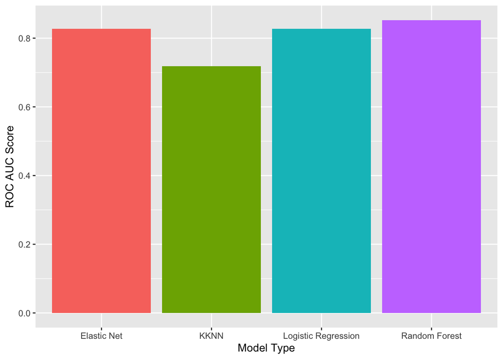

```r
# Adding Column to Merge On
best_en %>%
  mutate(model = "Elastic Net") -> best_en
best_kknn %>%
  mutate(model = "KKNN")  -> best_kknn
best_logreg %>%
  mutate(model = "Logistic Regression") -> best_logreg
best_rf %>%
  mutate(model = "Random Forest") -> best_rf

# Tibble of Best Models
best_models <- bind_rows(best_en, best_kknn, best_logreg, best_rf)

ggplot(best_models, aes(x = model, y = mean, fill = model)) +
  geom_bar(stat = "identity", position = "dodge") +
  xlab('Model Type') +
  ylab('ROC AUC Score') +
  theme(legend.position = "none")
```

# Optimal Model

Let’s load our optimal model, finalize it’s workflow, and analyze the variable importance plot on our training set.

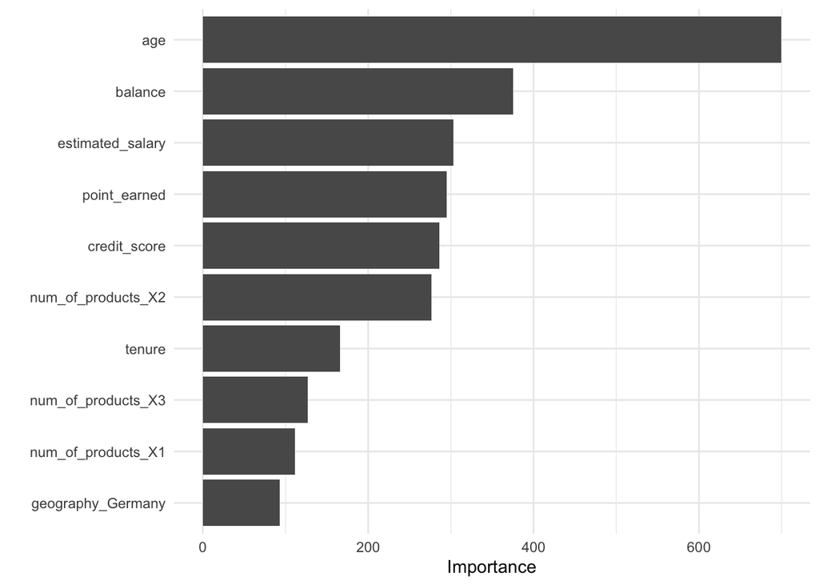

```r
final_ccr_rf <- select_best(ccr_rf_tune, metric = 'roc_auc')

optimal_model <- finalize_workflow(ccr_rf_wf, final_ccr_rf)
optimal_model <- fit(optimal_model, ccr_train)

optimal_model %>% extract_fit_parsnip() %>%
  vip() +
  theme_minimal()
```

The variable importance plot shows us which variables had the greatest impact on our outcome variable. Here we see that **age** has the most importance, with **balance** in second meaning that **age** and **balance** are the variables with the largest impact on the result of **exited**. We anticipated this result; in our correlation matrix from exploratory data analysis, these variables had a positive correlation with **exited**.  
Finally, let’s fit this model to our testing set.

```r
optimal_test <- augment(optimal_model, ccr_test) %>%
  select(exited, starts_with(".pred"))

roc_auc(optimal_test, truth = exited, .pred_0)
```

```
## # A tibble: 1 × 3
##   .metric .estimator .estimate
##   <chr>   <chr>          <dbl>
## 1 roc_auc binary         0.858
```

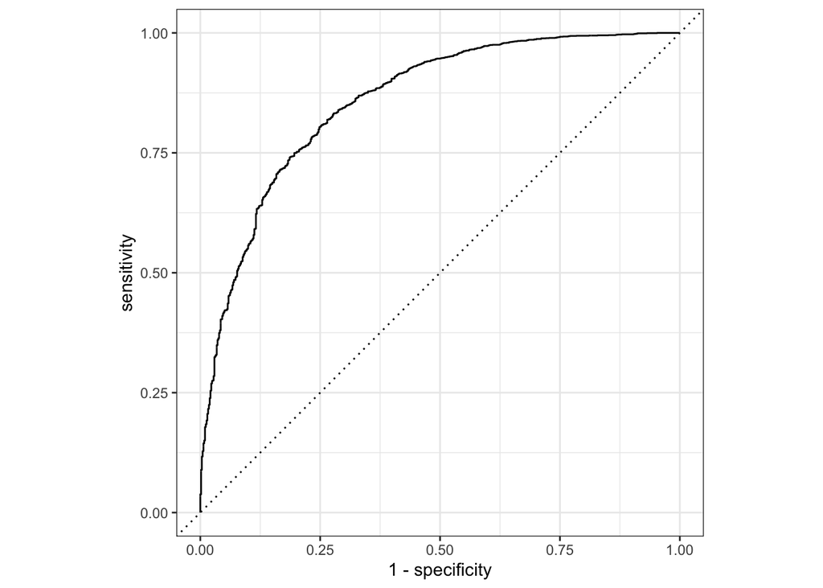

```r
roc_curve(optimal_test, truth = exited, .pred_0) %>%
  autoplot()
```

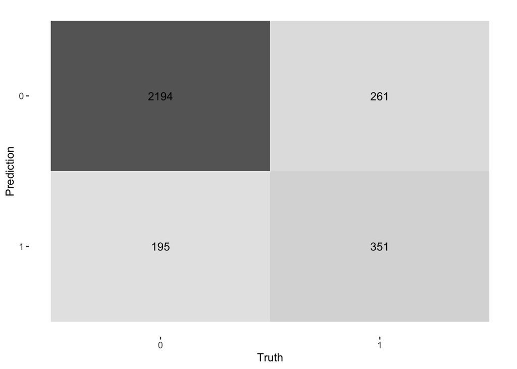

```r
conf_mat(optimal_test, truth = exited, .pred_class) %>%
  autoplot(type = "heatmap")
```

These statistics, along with the accompanying visuals, indicate that our model performs well overall, but performs better at predicting those that do not exit over those that do.